# Breed and Dog Type Sentiment Analysis

The analysis is based on the data collected from [WeRateDogs™](https://twitter.com/dog_rates) (further, Source) twitter account.

## Breed Sentiment Analysis

### Source Data

1. Predictive data of a dog breed based on images from Source - `twitter_archive_master.csv`
2. Number of likes - `tweet_data.csv`
3. Number of retweets - `tweet_data.csv`

### Analysis

First let's import the necessary libraries and load data sources.

```python
import pandas as pd
import matplotlib.pyplot as plt
import statsmodels.api as sm

df_dog_data = pd.read_csv('twitter_archive_master.csv')
df_tweet_data = pd.read_csv('tweet_data.csv')
```

Filter df_dog_data by results of high confidence.

```python
df_dog_data_conf = df_dog_data[df_dog_data.p1_conf > 0.75]
df_dog_data_conf.set_index('tweet_id', inplace=True)
```

Create a couple of handy functions for number crunching.

```python
def extractRatingByParameter(df):
    ratings = dict()

    def reduceRatingsToSeries(ser):
        if ser[1] in ratings.keys():
            ratings[ser[1]] = ratings[ser[1]].append(pd.Series(ser[0]))
        else:
            ratings[ser[1]] = pd.Series(ser[0])

    df.apply(reduceRatingsToSeries, axis=1)
    return ratings

def calculateAndSort(d, method = 'mean'):
    calcs = {x:getattr(d[x], method)() for x in d.keys()}
    return sorted(calcs.keys(), key=lambda dn: calcs[dn], reverse=True), calcs

def calculateAndSortAlpha(d, method = 'mean'):
    calcs = {x:getattr(d[x], method)() for x in d.keys()}
    return sorted(calcs.keys()), calcs
```

Let's see how well these functions work on average ratings for breeds.

```python
breed_ratings = extractRatingByParameter(df_dog_data_conf[['rating_numerator', 'p1']])
sorted_breeds, breed_ratings_mean = calculateAndSort(breed_ratings)
for b in sorted_breeds:
    print(b, breed_ratings_mean[b])
```

```
chow 13.0
cardigan 13.0
siberian_husky 13.0
briard 13.0
staffordshire_bullterrier 13.0
samoyed 13.0
chihuahua 13.0
french_bulldog 12.5
shetland_sheepdog 12.0
malamute 12.0
golden_retriever 11.875
pembroke 11.8
american_staffordshire_terrier 11.5
pomeranian 11.375
labrador_retriever 11.333333333333334
great_pyrenees 11.0
dalmatian 11.0
papillon 11.0
toy_poodle 11.0
lakeland_terrier 11.0
pug 10.6
miniature_pinscher 10.5
bernese_mountain_dog 10.0
cocker_spaniel 10.0
maltese_dog 10.0
german_short-haired_pointer 10.0
blenheim_spaniel 9.0
boxer 9.0
whippet 9.0
```

Now let's run the same analysis on likes and retweets and create a handy intermittent data frame that will be used in calculations.

```python
breed_likes = extractRatingByParameter(df_dog_data_conf.join(df_tweet_data.set_index('tweet_id'))[['likes', 'p1']])
breed_retweets = extractRatingByParameter(df_dog_data_conf.join(df_tweet_data.set_index('tweet_id'))[['retweets', 'p1']])

breeds, mean_ratings = calculateAndSortAlpha(breed_ratings)
breeds, mean_likes = calculateAndSortAlpha(breed_likes)
breeds, mean_retweets = calculateAndSortAlpha(breed_retweets)

df_mean_ratings_likes = pd.DataFrame({'breed': breeds,
                                      'ratings': list(mean_ratings.values()),
                                      'likes': list(mean_likes.values()),
                                      'retweets': list(mean_retweets.values())})

df_mean_ratings_likes = df_mean_ratings_likes.dropna()
```

Now let's run regression analysis on ratings, likes and retweets in relation to the breed and see if breed affects the results.

```python
df_mean_ratings_likes['intercept'] = 1
```

```python
sm.OLS(df_mean_ratings_likes['likes'], df_mean_ratings_likes[['ratings', 'intercept']], missing='drop').fit().summary()
```

OLS Regression Results

| Dep. Variable: | likes | R-squared: | 0.207 |
| --- | --- | --- | --- |
| Model: | OLS | Adj. R-squared: | 0.161 |
| Method: | Least Squares | F-statistic: | 4.449 |
| Date: | Sun, 09 Dec 2018 | Prob (F-statistic): | 0.0500 |
| Time: | 12:07:41 | Log-Likelihood: | -209.13 |
| No. Observations: | 19 | AIC: | 422.3 |
| Df Residuals: | 17 | BIC: | 424.2 |
| Df Model: | 1 |  |  |
| Covariance Type: | nonrobust |  |  |

|  | coef | std err | t | P>\|t\| | [0.025 | 0.975] |
| --- | --- | --- | --- | --- | --- | --- |
| ratings | 6976.8962 | 3307.608 | 2.109 | 0.050 | -1.547 | 1.4e+04 |
| intercept | -6.171e+04 | 3.91e+04 | -1.577 | 0.133 | -1.44e+05 | 2.09e+04 |

| Omnibus: | 15.823 | Durbin-Watson: | 2.173 |
| --- | --- | --- | --- |
| Prob(Omnibus): | 0.000 | Jarque-Bera (JB): | 15.341 |
| Skew: | 1.603 | Prob(JB): | 0.000466 |
| Kurtosis: | 6.017 | Cond. No. | 132. |

Warnings:  
[1] Standard Errors assume that the covariance matrix of the errors is correctly specified.

```python
sm.OLS(df_mean_ratings_likes.retweets, df_mean_ratings_likes[['ratings', 'intercept']], missing='drop').fit().summary()
```

OLS Regression Results

| Dep. Variable: | retweets | R-squared: | 0.172 |
| --- | --- | --- | --- |
| Model: | OLS | Adj. R-squared: | 0.123 |
| Method: | Least Squares | F-statistic: | 3.530 |
| Date: | Sun, 09 Dec 2018 | Prob (F-statistic): | 0.0775 |
| Time: | 12:07:41 | Log-Likelihood: | -188.49 |
| No. Observations: | 19 | AIC: | 381.0 |
| Df Residuals: | 17 | BIC: | 382.9 |
| Df Model: | 1 |  |  |
| Covariance Type: | nonrobust |  |  |

|  | coef | std err | t | P>\|t\| | [0.025 | 0.975] |
| --- | --- | --- | --- | --- | --- | --- |
| ratings | 2096.1514 | 1115.716 | 1.879 | 0.078 | -257.803 | 4450.106 |
| intercept | -1.872e+04 | 1.32e+04 | -1.418 | 0.174 | -4.66e+04 | 9127.448 |

| Omnibus: | 3.499 | Durbin-Watson: | 2.241 |
| --- | --- | --- | --- |
| Prob(Omnibus): | 0.174 | Jarque-Bera (JB): | 2.213 |
| Skew: | 0.835 | Prob(JB): | 0.331 |
| Kurtosis: | 3.062 | Cond. No. | 132. |

Warnings:  
[1] Standard Errors assume that the covariance matrix of the errors is correctly specified.

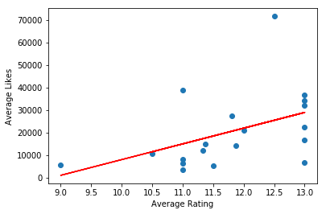

```python
plt.scatter(df_mean_ratings_likes.ratings, df_mean_ratings_likes.likes);
plt.plot(df_mean_ratings_likes.ratings, df_mean_ratings_likes.ratings * 6977 - 61710, color='red');
plt.xlabel('Average Rating');
plt.ylabel('Average Likes');
```

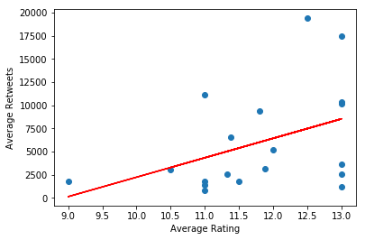

```python
plt.scatter(df_mean_ratings_likes.ratings, df_mean_ratings_likes.retweets);
plt.plot(df_mean_ratings_likes.ratings, df_mean_ratings_likes.ratings * 2096 - 18720, color='red');
plt.xlabel('Average Rating');
plt.ylabel('Average Retweets');
```

## Dog Type Sentiment Analysis

### Source Data

Same as in the Breed Sentiment Analysis.

### Analysis

Let's compare and visualise the ratings for dog type.

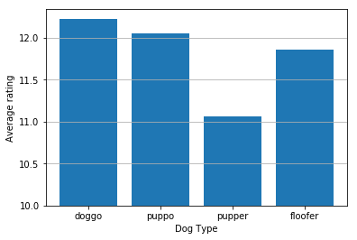

```python
type_ratings = extractRatingByParameter(df_dog_data[['rating_numerator', 'dog_type']])
type_ratings_mean = {b:type_ratings[b].mean() for b in type_ratings.keys()}
plt.bar(list(type_ratings_mean.keys()), list(map(lambda v: v - 10, type_ratings_mean.values())), bottom=[10] * 4);
plt.xlabel('Dog Type');
plt.ylabel('Average rating');
plt.grid(axis='y')
```

Seems like `doggo`s are treated more favourably by authors. Let's see if that holds true from statistics point of view.

```python
df_dog_data_reind = df_dog_data.set_index('tweet_id')
df_dog_data_w_dummies = df_dog_data_reind.join(pd.get_dummies(df_dog_data_reind.dog_type)).join(df_tweet_data.set_index('tweet_id'))
df_dog_data_w_dummies = df_dog_data_w_dummies.dropna()
df_dog_data_w_dummies['intercept'] = 1

sm.OLS(df_dog_data_w_dummies['rating_numerator'], df_dog_data_w_dummies[['intercept', 'doggo', 'puppo', 'pupper']]).fit().summary()
```

OLS Regression Results

| Dep. Variable: | rating_numerator | R-squared: | 0.080 |
| --- | --- | --- | --- |
| Model: | OLS | Adj. R-squared: | 0.044 |
| Method: | Least Squares | F-statistic: | 2.213 |
| Date: | Sun, 09 Dec 2018 | Prob (F-statistic): | 0.0934 |
| Time: | 12:07:42 | Log-Likelihood: | -132.42 |
| No. Observations: | 80 | AIC: | 272.8 |
| Df Residuals: | 76 | BIC: | 282.4 |
| Df Model: | 3 |  |  |
| Covariance Type: | nonrobust |  |  |

|  | coef | std err | t | P>\|t\| | [0.025 | 0.975] |
| --- | --- | --- | --- | --- | --- | --- |
| intercept | 12.2000 | 0.581 | 20.993 | 0.000 | 11.043 | 13.357 |
| doggo | -0.0077 | 0.635 | -0.012 | 0.990 | -1.272 | 1.256 |
| puppo | -0.2000 | 0.661 | -0.303 | 0.763 | -1.517 | 1.117 |
| pupper | -0.8250 | 0.625 | -1.320 | 0.191 | -2.070 | 0.420 |

| Omnibus: | 3.452 | Durbin-Watson: | 1.138 |
| --- | --- | --- | --- |
| Prob(Omnibus): | 0.178 | Jarque-Bera (JB): | 3.019 |
| Skew: | -0.381 | Prob(JB): | 0.221 |
| Kurtosis: | 2.429 | Cond. No. | 9.38 |

Warnings:  
[1] Standard Errors assume that the covariance matrix of the errors is correctly specified.

The analysis shows that this is not so, there's a weak and statistically insignificant correlation between dog type and the rating it get. "They're Good Dogs Brent", indeed.